# rbanoth_FML_A5

Group 1

2024-04-07

#Loading required packages

```r
library(cluster)
library(caret)
library(dendextend)
library(knitr)
library(factoextra)
library(ISLR)
library(dplyr)
library(tidyverse)
library(proxy)
library(NbClust)
library(ppclust)
```

```r
library(tinytex)
library(ggplot2)
```

#Considering “df.cereal” as our dataframe and load Cerials dataset and summarise it

```r
df.cereal <- read.csv("C:/Users/banot/Downloads/Cereals.csv")
head(df.cereal)
```

```
##                        name mfr type calories protein fat sodium fiber carbo
## 1                 100%_Bran   N    C       70       4   1    130  10.0   5.0
## 2         100%_Natural_Bran   Q    C      120       3   5     15   2.0   8.0
## 3                  All-Bran   K    C       70       4   1    260   9.0   7.0
## 4 All-Bran_with_Extra_Fiber   K    C       50       4   0    140  14.0   8.0
## 5            Almond_Delight   R    C      110       2   2    200   1.0  14.0
## 6   Apple_Cinnamon_Cheerios   G    C      110       2   2    180   1.5  10.5
##   sugars potass vitamins shelf weight cups   rating
## 1      6    280       25     3      1 0.33 68.40297
## 2      8    135        0     3      1 1.00 33.98368
## 3      5    320       25     3      1 0.33 59.42551
## 4      0    330       25     3      1 0.50 93.70491
## 5      8     NA       25     3      1 0.75 34.38484
## 6     10     70       25     1      1 0.75 29.50954
```

```r
summary(df.cereal)
```

```
##      name               mfr                type              calories
##  Length:77          Length:77          Length:77          Min.   : 50.0
##  Class :character   Class :character   Class :character   1st Qu.:100.0
##  Mode  :character   Mode  :character   Mode  :character   Median :110.0
##                                                           Mean   :106.9
##                                                           3rd Qu.:110.0
##                                                           Max.   :160.0
##
##     protein           fat            sodium          fiber
##  Min.   :1.000   Min.   :0.000   Min.   :  0.0   Min.   : 0.000
##  1st Qu.:2.000   1st Qu.:0.000   1st Qu.:130.0   1st Qu.: 1.000
##  Median :3.000   Median :1.000   Median :180.0   Median : 2.000
##  Mean   :2.545   Mean   :1.013   Mean   :159.7   Mean   : 2.152
##  3rd Qu.:3.000   3rd Qu.:2.000   3rd Qu.:210.0   3rd Qu.: 3.000
##  Max.   :6.000   Max.   :5.000   Max.   :320.0   Max.   :14.000
##
##      carbo          sugars           potass          vitamins
##  Min.   : 5.0   Min.   : 0.000   Min.   : 15.00   Min.   :  0.00
##  1st Qu.:12.0   1st Qu.: 3.000   1st Qu.: 42.50   1st Qu.: 25.00
##  Median :14.5   Median : 7.000   Median : 90.00   Median : 25.00
##  Mean   :14.8   Mean   : 7.026   Mean   : 98.67   Mean   : 28.25
##  3rd Qu.:17.0   3rd Qu.:11.000   3rd Qu.:120.00   3rd Qu.: 25.00
##  Max.   :23.0   Max.   :15.000   Max.   :330.00   Max.   :100.00
##  NA's   :1      NA's   :1        NA's   :2
##      shelf           weight          cups           rating
##  Min.   :1.000   Min.   :0.50   Min.   :0.250   Min.   :18.04
##  1st Qu.:1.000   1st Qu.:1.00   1st Qu.:0.670   1st Qu.:33.17
##  Median :2.000   Median :1.00   Median :0.750   Median :40.40
##  Mean   :2.208   Mean   :1.03   Mean   :0.821   Mean   :42.67
##  3rd Qu.:3.000   3rd Qu.:1.00   3rd Qu.:1.000   3rd Qu.:50.83
##  Max.   :3.000   Max.   :1.50   Max.   :1.500   Max.   :93.70
##
```

#Structure and dimention of the dataset

```r
str(df.cereal)
```

```
## 'data.frame':    77 obs. of  16 variables:
##  $ name    : chr  "100%_Bran" "100%_Natural_Bran" "All-Bran" "All-Bran_with_Extra_Fiber" ...
##  $ mfr     : chr  "N" "Q" "K" "K" ...
##  $ type    : chr  "C" "C" "C" "C" ...
##  $ calories: int  70 120 70 50 110 110 110 130 90 90 ...
##  $ protein : int  4 3 4 4 2 2 2 3 2 3 ...
##  $ fat     : int  1 5 1 0 2 2 0 2 1 0 ...
##  $ sodium  : int  130 15 260 140 200 180 125 210 200 210 ...
##  $ fiber   : num  10 2 9 14 1 1.5 1 2 4 5 ...
##  $ carbo   : num  5 8 7 8 14 10.5 11 18 15 13 ...
##  $ sugars  : int  6 8 5 0 8 10 14 8 6 5 ...
##  $ potass  : int  280 135 320 330 NA 70 30 100 125 190 ...
##  $ vitamins: int  25 0 25 25 25 25 25 25 25 25 ...
##  $ shelf   : int  3 3 3 3 3 1 2 3 1 3 ...
##  $ weight  : num  1 1 1 1 1 1 1 1.33 1 1 ...
##  $ cups    : num  0.33 1 0.33 0.5 0.75 0.75 1 0.75 0.67 0.67 ...
##  $ rating  : num  68.4 34 59.4 93.7 34.4 ...
```

```r
dim(df.cereal)
```

```
## [1] 77 16
```

Preparing Data #Before the NA (Null) values are eliminated from the data set, the data will be scaled.

```r
#Make a copy of the data set for preparation.
scaled.df <- df.cereal
#Before feeding the data set into a clustering method, scale it.
scaled.df[,c(4:16)] <- scale(df.cereal[,c(4:16)])
#Take NA values out of the dataset.
pp.df <- na.omit(scaled.df)
head(pp.df)
```

```
##                        name mfr type   calories    protein         fat
## 1                 100%_Bran   N    C -1.8929836  1.3286071 -0.01290349
## 2         100%_Natural_Bran   Q    C  0.6732089  0.4151897  3.96137277
## 3                  All-Bran   K    C -1.8929836  1.3286071 -0.01290349
## 4 All-Bran_with_Extra_Fiber   K    C -2.9194605  1.3286071 -1.00647256
## 6   Apple_Cinnamon_Cheerios   G    C  0.1599704 -0.4982277  0.98066557
## 7               Apple_Jacks   K    C  0.1599704 -0.4982277 -1.00647256
##       sodium       fiber      carbo     sugars     potass   vitamins      shelf
## 1 -0.3539844  3.29284661 -2.5087829 -0.2343906  2.5753685 -0.1453172  0.9515734
## 2 -1.7257708 -0.06375361 -1.7409943  0.2223705  0.5160205 -1.2642598  0.9515734
## 3  1.1967306  2.87327158 -1.9969238 -0.4627711  3.1434645 -0.1453172  0.9515734
## 4 -0.2346986  4.97114672 -1.7409943 -1.6046739  3.2854885 -0.1453172  0.9515734
## 6  0.2424445 -0.27354112 -1.1011705  0.6791317 -0.4071355 -0.1453172 -1.4507595
## 7 -0.4136273 -0.48332864 -0.9732057  1.5926539 -0.9752315 -0.1453172 -0.2495930
##       weight       cups     rating
## 1 -0.1967771 -2.1100340  1.8321876
## 2 -0.1967771  0.7690100 -0.6180571
## 3 -0.1967771 -2.1100340  1.1930986
## 4 -0.1967771 -1.3795303  3.6333849
## 6 -0.1967771 -0.3052601 -0.9365625
## 7 -0.1967771  0.7690100 -0.6756899
```

##Task A #With the normalized measurements as the Euclidean distance, apply hierarchical clustering to the data. To compare the clustering from single, complete, average, and Ward linkages, use Agnes. Select the most effective approach.

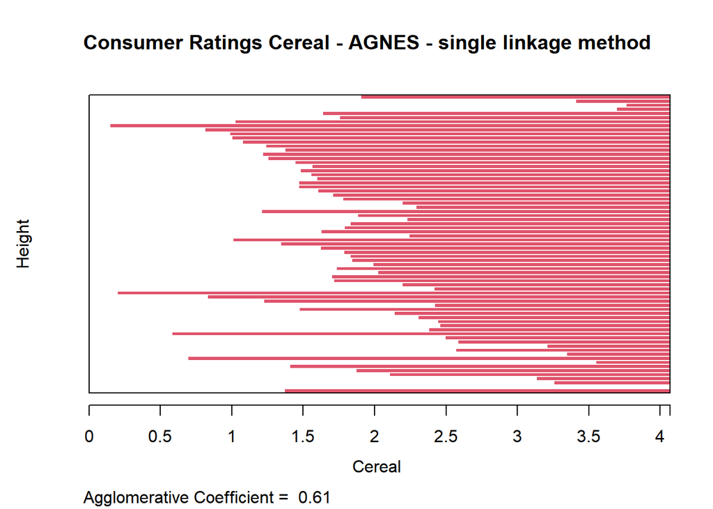

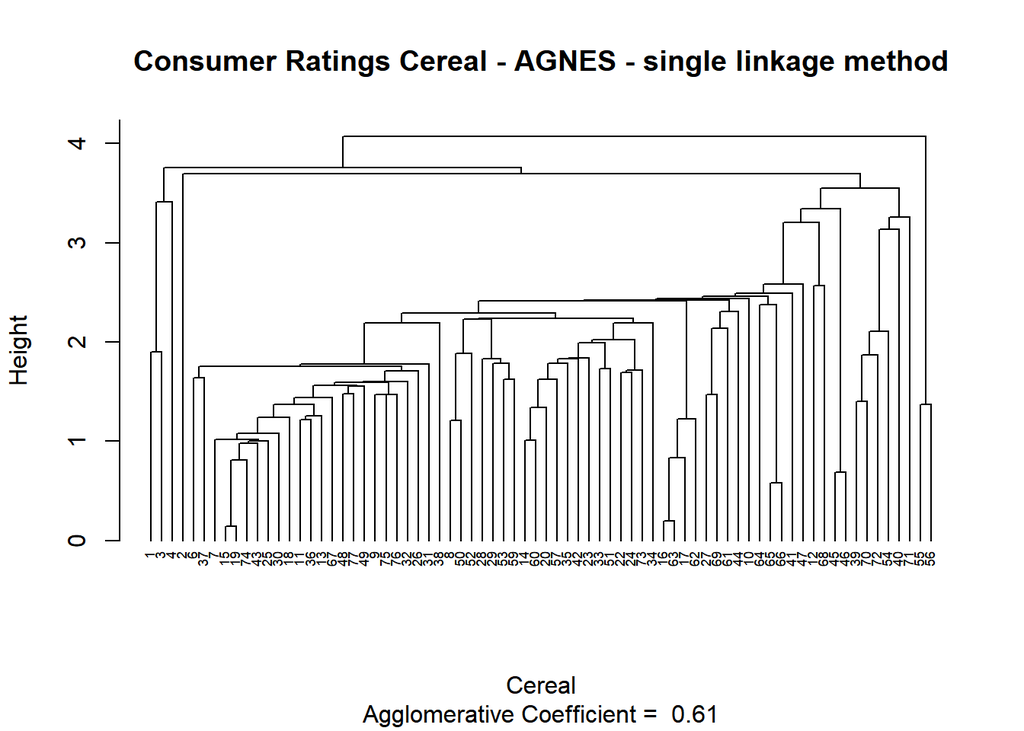

```r
#1.single linkage

#Make use of Euclidean distance measurements to create the dissimilarity matrix for the data set's numerical values.
euclidean.df_d <- dist(pp.df[,c(4:16)],method = "euclidean")
#Use the single linkage approach to perform hierarchical clustering.
single.hc_agnes <- agnes(euclidean.df_d,method = "single")
#Plot the outcomes of the various techniques.
plot(single.hc_agnes,main = "Consumer Ratings Cereal - AGNES - single linkage method",xlab = "Cereal",ylab = "Height",cex.axis = 1,cex = 0.56,hang = -1)
```

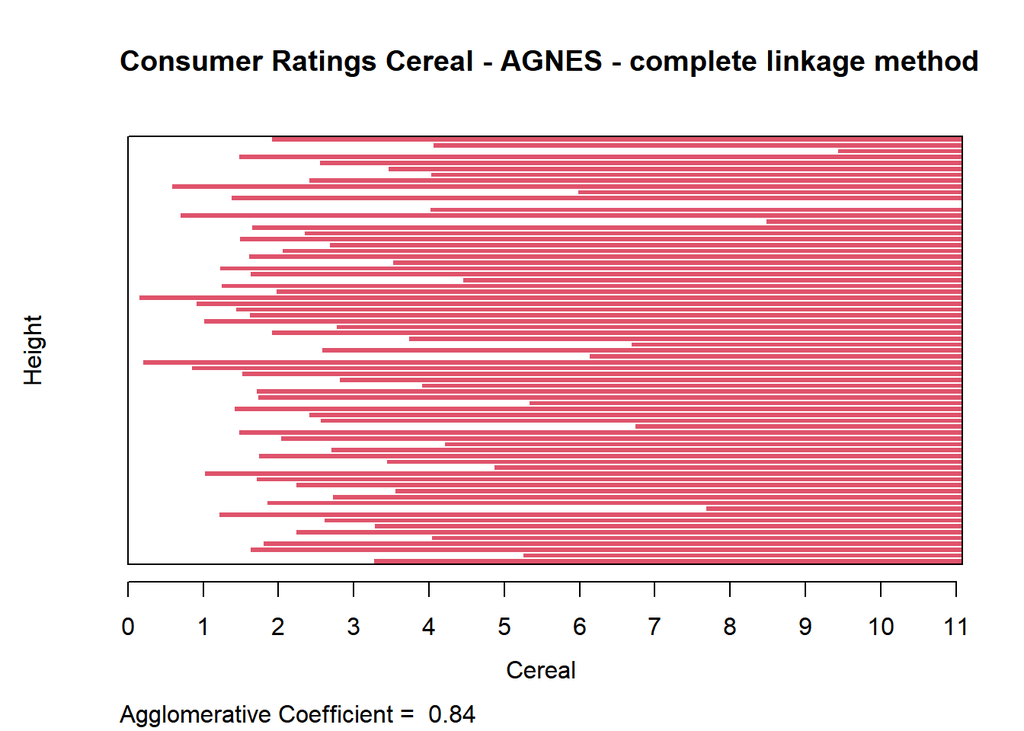

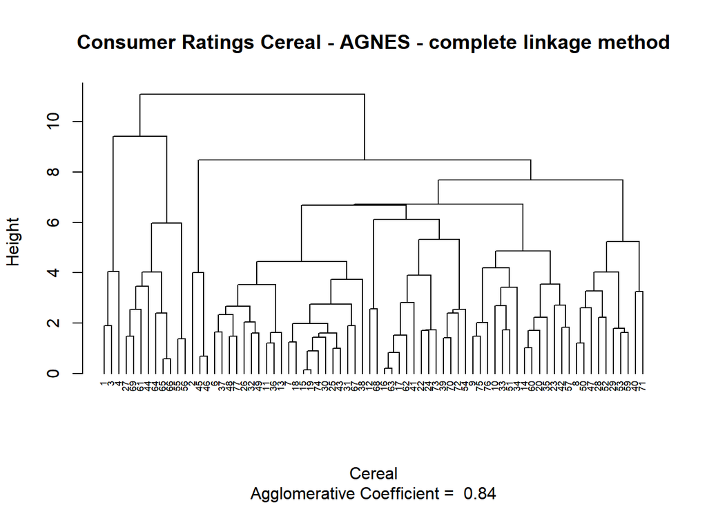

```r
#2.Complete linkage
complete.hc_agnes <- agnes(euclidean.df_d,method = "complete")
#Plot the outcomes of the various techniques
plot(complete.hc_agnes,main = "Consumer Ratings Cereal - AGNES - complete linkage method",xlab = "Cereal",ylab = "Height",cex.axis = 1,cex = 0.56,hang = -1)
```

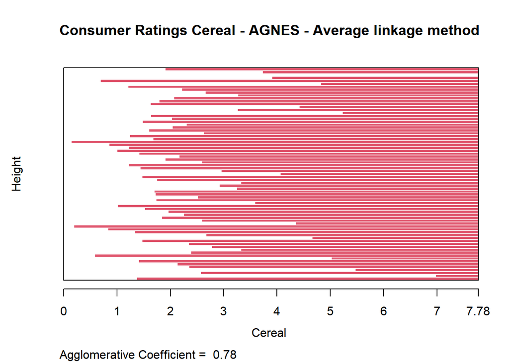

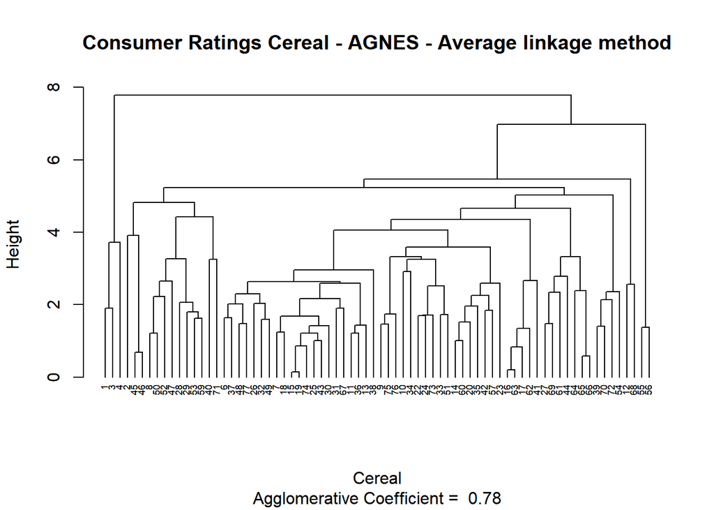

```r
#3.Average Linkage
#hierarchical clustering via the average linkage method
average.hc_agnes <- agnes(euclidean.df_d, method = "average")
plot(average.hc_agnes,main = "Consumer Ratings Cereal - AGNES - Average linkage method",xlab = "Cereal",ylab = "Height",cex.axis = 1,cex = 0.56,hang = -1)
```

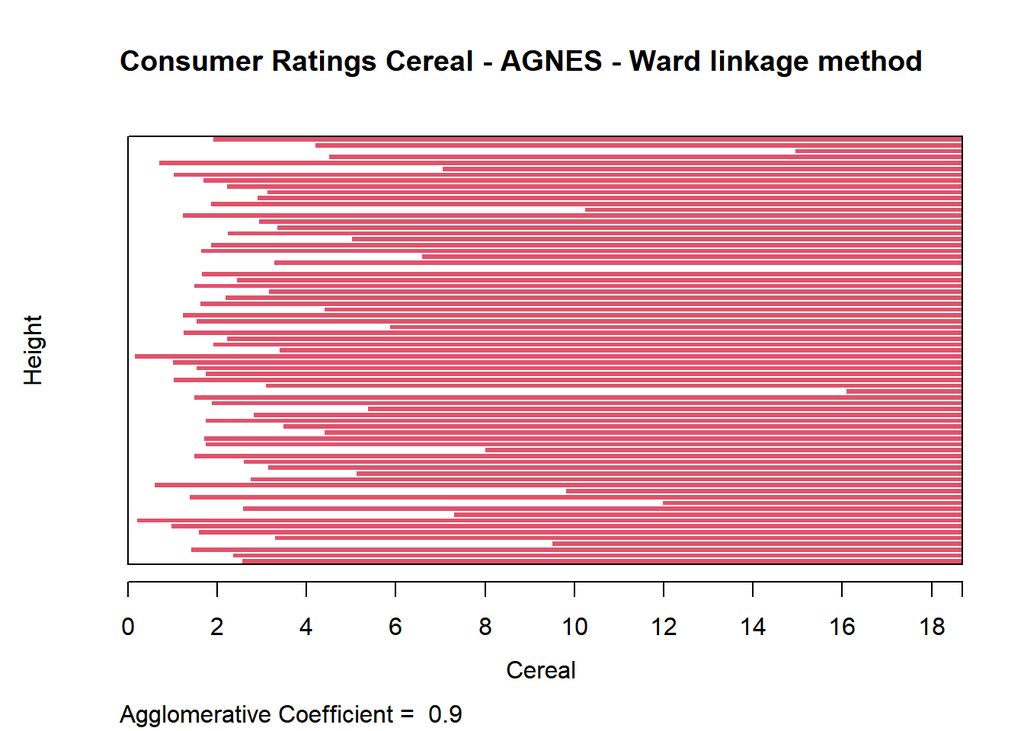

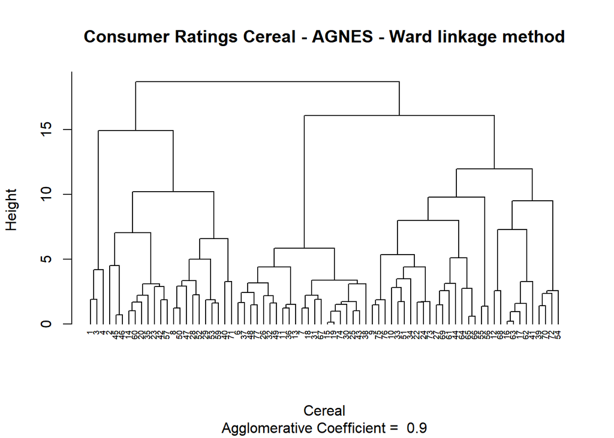

```r
#4.Ward Linkage Method
#hierarchical clustering via the ward linkage method
ward.hc_agnes <- agnes(euclidean.df_d,method = "ward")
plot(ward.hc_agnes,main = "Consumer Ratings Cereal - AGNES - Ward linkage method",xlab = "Cereal",ylab = "Height",cex.axis = 1,cex = 0.56,hang = -1)
```

#Based on the agglomerative coefficient that is obtained from each method, the optimal clustering technique would be chosen. The clustering structure is closer the closer the value is to 1.0. As a result, the approach that yields a result closest to 1.0 will be selected. For Single Linkage: 0.61, Complete Linkage: 0.84, Average Linkage: 0.78 and Ward Method: 0.90

Conclusion: Consequently, the Ward approach will be selected as the optimal clustering model for this particular case.

##Task2 #The elbow and silhouette approaches will be used to calculate the ideal number of clusters.

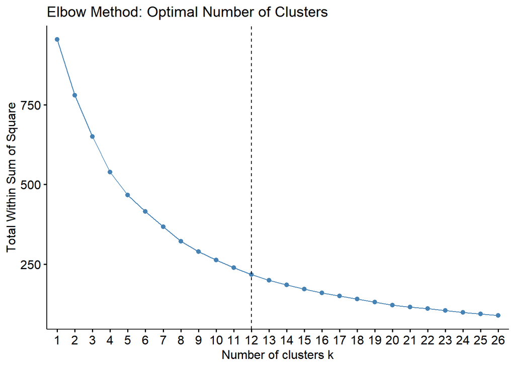

```r
#1.Elbow method
fviz_nbclust(pp.df[,c(4:16)],hcut,method = "wss",k.max = 26) + labs(title = "Elbow Method: Optimal Number of Clusters") + geom_vline(xintercept = 12,linetype = 2)
```

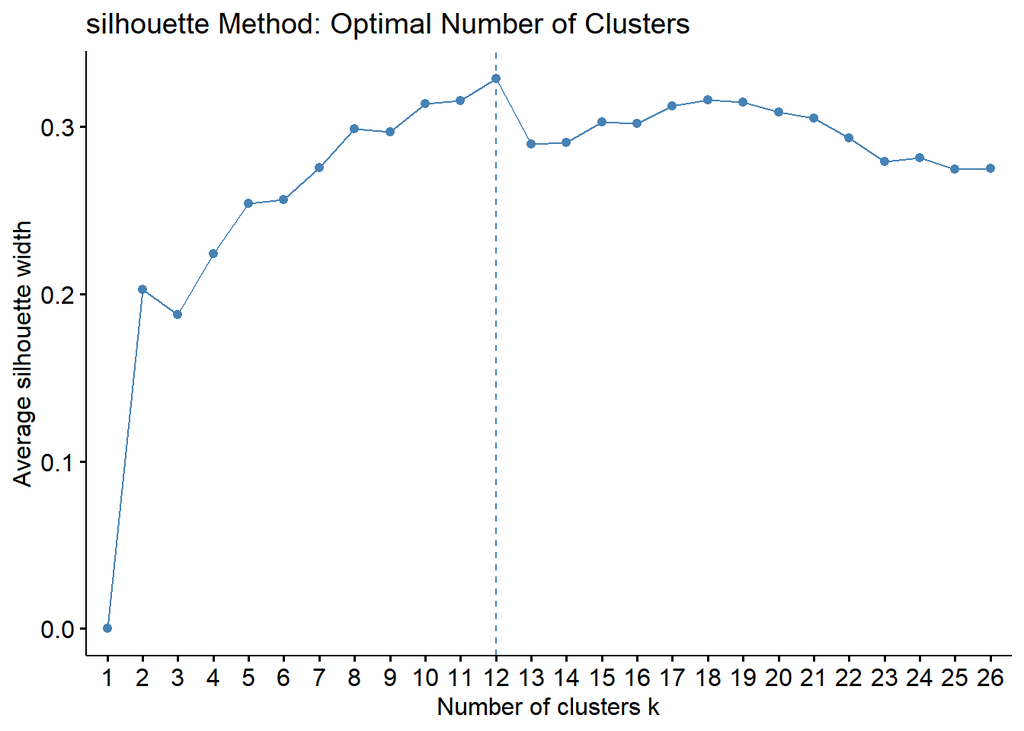

```r
#2.Silhouette Method
fviz_nbclust(pp.df[,c(4:16)],hcut,method = "silhouette",k.max = 26) + labs(title = "silhouette Method: Optimal Number of Clusters")
```

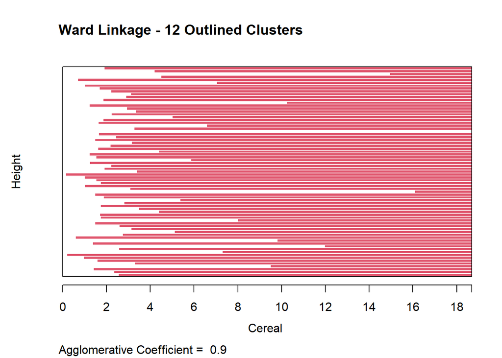

```r
#The 12 clusters on the hierarchical tree are described below

#The reference plot displays the 12 clusters of the Ward hierarchical tree.
plot(ward.hc_agnes,main = "Ward Linkage - 12 Outlined Clusters", xlab = "Cereal", ylab = "Height",cex.axis = 1,cex = 0.56,hang = -1)
```

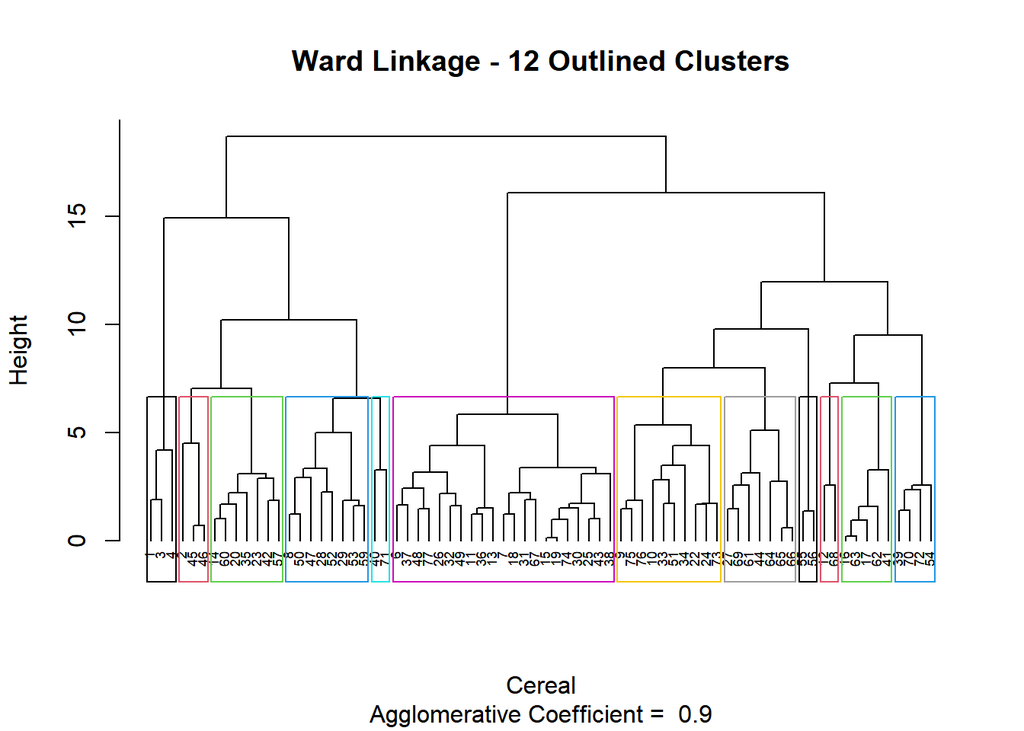

```r
rect.hclust(ward.hc_agnes,k=12,border = 1:12)
```

##Task 3

#Every Cluster Assigned to Data: #All data sets’ assigned clusters may be found in “preprocessed.df_1”

```r
ward_12 <- cutree(ward.hc_agnes,k=12)
preprocessed.df_1 <- cbind(cluster = ward_12,pp.df)
```

```r
#A 70/30 division of the data set will be created in order to test the stability of the clusters. After cluster assignments are created using the 70%, the remaining 30% will be assigned according to the centroid that is closest to them.

set.seed(143)
index_cereal <- createDataPartition(pp.df$protein,p=0.3,list = FALSE)
ppc_partB <- pp.df[index_cereal,]
ppc_partA <- pp.df[-index_cereal,]
```

##Re-Perform Partitioned Data Clustering: #To assess the stability of the clusters, we will use the same ward clustering technique and K value (12) for the sake of this job. Next, for clusters 1 through 12, we shall allocate clusters to the closest points in Partition B.

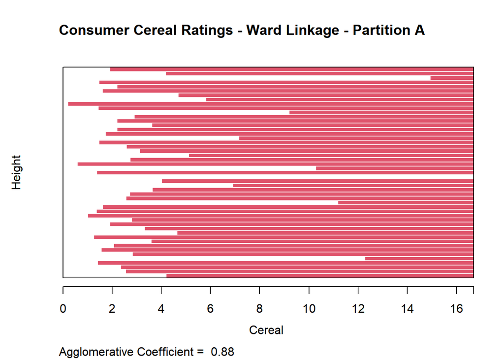

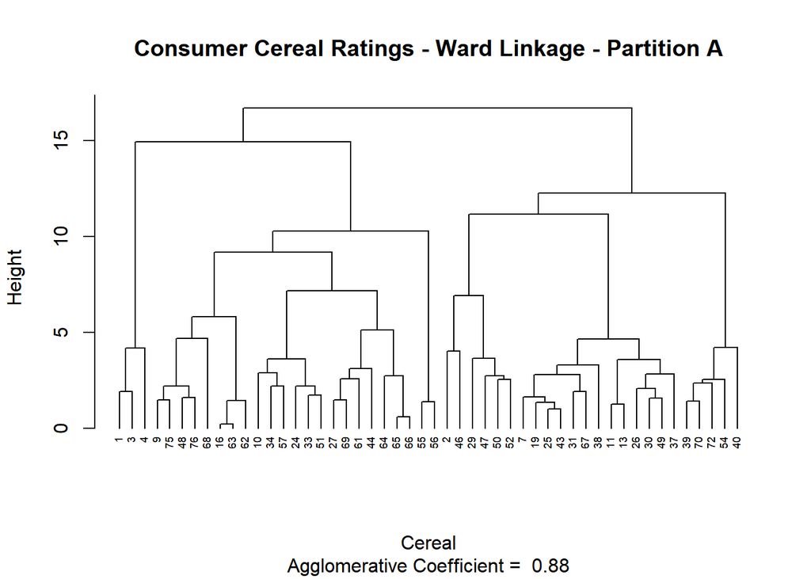

```r
#Apply the ward linkage method for hierarchical clustering to partitioned data.
A.euclidean_d <- dist(ppc_partA[,c(4:16)],method = "euclidean")
A.ward_hc_agnes <- agnes(A.euclidean_d,method = "ward")
plot(A.ward_hc_agnes,main = "Consumer Cereal Ratings - Ward Linkage - Partition A",xlab="Cereal",ylab="Height",cex.axis=1,cex=0.56,hang=-1)
```

```r
#For analysis, divide the tree into 12 clusters.
ward_df.A_12clusters <- cutree(A.ward_hc_agnes,k=12)
pp_cereal.A <- cbind(cluster = ward_df.A_12clusters,ppc_partA)

#To determine which centroidal of the clusters is closest to the data points in partition B, we must compute the centroids for each cluster
Centroid_ward.A <- aggregate(pp_cereal.A[,5:17],list(pp_cereal.A$cluster),mean)
Centroid_ward.A <- data_frame(cluster = Centroid_ward.A[,1],centroid = rowMeans(Centroid_ward.A[,-c(1:4)]))
Centroid_ward.A <- Centroid_ward.A$Centroid
#Determine the Partition B data set's centers
ppc_partB_centers <- data.frame(ppc_partB[,1:3],center = rowMeans(ppc_partB[,4:16]))
```

```r
#Based on the shortest distance between cluster centers, assign the clusters.
pp_cereal.B <- cbind(cluster =
c(4,8,7,3,5,6,7,11,11,10,8,5,10,1,10,1,4,12,12,7,7,1,4,9),
ppc_partB)
#Combine A and B partitions to compare them to the original clusters
pp2 <- rbind(pp_cereal.A,pp_cereal.B)
preprocessed.df_1 <- preprocessed.df_1[order(preprocessed.df_1$name),]
pp2 <- pp2[order(pp2$name),]

#After assigning the data using both approaches (full data and partitioned data), we can assess the stability of the clusters by comparing the number of matched assignments.

sum(preprocessed.df_1$cluster == pp2$cluster)
```

```
## [1] 24
```

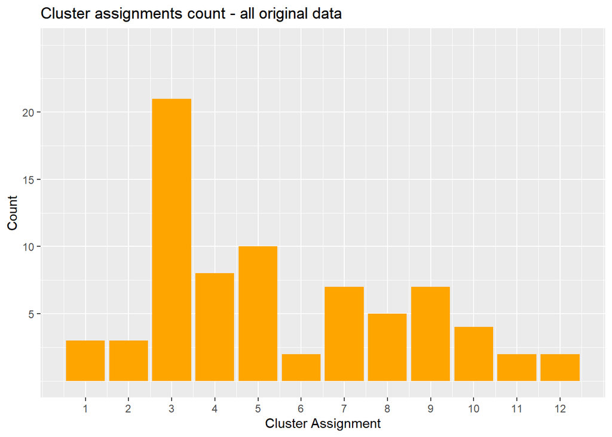

```r
#Check for differences between the two
#Plots of the original hierarchical clustering technique by visualizing the cluster allocations
ggplot(data = preprocessed.df_1,aes(preprocessed.df_1$cluster)) + geom_bar(fill = "orange") + labs(title = "Cluster assignments count - all original data") + labs(x="Cluster Assignment",y="Count") + guides(fill = FALSE) + scale_x_continuous(breaks=c(1:12)) +
scale_y_continuous(breaks=c(5,10,15,20), limits = c(0,25))
```

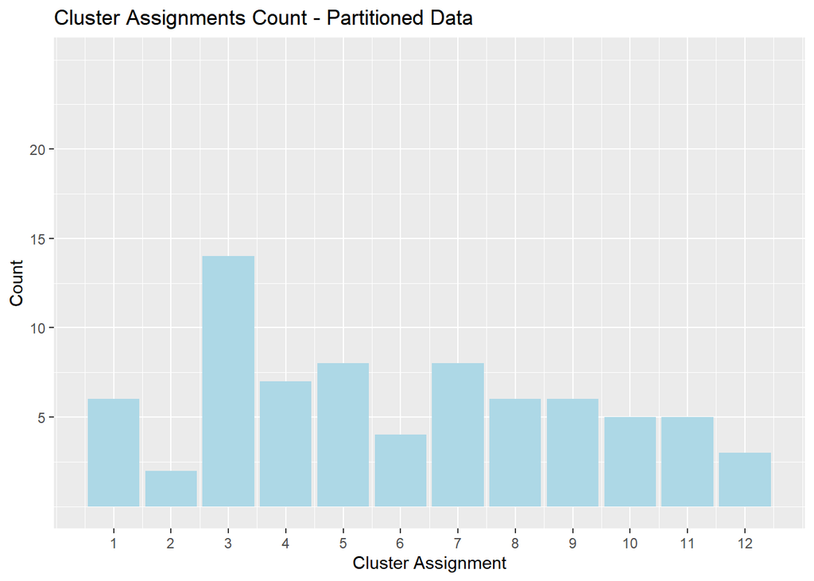

```r
#Plot of the algorithm that was divided before the remaining data was assigned
ggplot(data = pp2, aes(pp2$cluster)) +
geom_bar(fill = "lightblue") +
labs(title="Cluster Assignments Count - Partitioned Data") +
labs(x="Cluster Assignment", y="Count") +
guides(fill=FALSE) +
scale_x_continuous(breaks=c(1:12)) +
scale_y_continuous(breaks=c(5,10,15,20), limits = c(0,25))
```

#Using the partitioned data, Cluster 3 dramatically shrank, as can be seen visually. Because of this, a few of the other clusters grew larger. It appears from the chart that when the data is partitioned, the clusters are more evenly distributed throughout the 12 clusters.

##Task4

Ans: Normalizing the data would not be suitable in this situation. It wouldn’t be acceptable because the nutritional information for cereal is scaled and normalized based on the cereal sample that is being studied. As a result, the data set that was collected might only contain cereals that are extremely high in sugar and extremely low in iron, fiber, and other nutrients. It is hard to say how much nutrients the cereal will supply a child once it has been scaled or standardized throughout the sample set. Uninformed viewers would believe that a cereal with an iron score of 0.999 indicates it contains virtually all the necessary iron for a child’s diet; nevertheless, it might merely be the best of the worst in the sample set, with essentially little nutritional value.

Consequently, preparing the data as a ratio to a child’s daily recommended intake of calories, fiber, carbs, etc. would be a more appropriate way to handle the data. When evaluating, this would enable analysts to make more educated decisions regarding the clusters, but not Permit a few more significant variables to influence the distance estimates. An analyst looking at the clusters may find out how much of a student’s daily recommended nutrition would come from XX cereal by looking at the cluster average. This would make it possible for the employees to choose among the “healthy” cereal clusters with knowledge.